# Waterlogging qPCR Analysis

## Setup

```r
cq_threshold <- 0.7 # Threshold for difference between triplicate Cq values
max_cq       <- 35 # Maximum Cq value to keep

here         <- here::here() # Set working directory to location of this file
data_dir     <- file.path(here, "..", "Data") |> normalizePath() # Data
fig_dir      <- file.path(here, "figures", "qPCR") # Figures
```

```r
kbl <- function(...) {
  kable(...) |> kable_styling()
}
```

## Load qPCR Data

Load qPCR data from csv files exported from the qPCR machine. Store data from each plate in a list containing data.tables for samples, standards, and NTCs.

```r
#' Load qPCR data from a csv file
#' @param file_path The path to the csv file
#' @param header_rows The number of header rows to skip
#' @param columns The columns to select
#' @return A list containing the samples, standards, and NTCs as data.tables
#'
load_qpcr_data <- function(file_path, header_rows = 19, columns = data_cols) {


  # Read the csv file and skip the header rows
  data <- fread(
    file = file_path, skip = header_rows, select = columns,
    na.strings = c("", "NA", "NaN", "None"), fill = TRUE
  )
  setnames(data, "Starting Quantity (SQ)", "Concentration")

  # Get plate number from file name
  # Add plate number to the data
  plate <- as.numeric(gsub(".* plate (\\d+).*", "\\1", basename(file_path)))
  data[, Plate := plate]

  # Rename Content values
  data[, Content := fcase(
    startsWith(Content, "Unkn"), "Sample",
    startsWith(Content, "Std"), "Standard",
    startsWith(Content, "NTC"), "NTC"
  )]

  # Add Type column based on Content
  data[Content == "Sample", Type := fcase(
    Sample %in% unlist(roots), "Root",
    Sample %in% unlist(soil), "Soil"
  )]
  data[Content == "Standard", Type := fcase(
    startsWith(Sample, "Sr"), "Root",
    startsWith(Sample, "Ss"), "Soil"
  )]

  # Add leading 0 to samples for sorting
  data[Content == "Sample", Sample := sprintf("%02d", as.numeric(Sample))]

  # Calculate sample concentration
  data[, Dilution := as.numeric(Dilution)]
  data[Content == "Sample", Concentration := 1 / as.numeric(Dilution)]
  data[Content == "Standard", Dilution := 1 / as.numeric(Concentration)]
  data[, log10_concentration := log10(Concentration)]

  # Construct the plate object
  list(
    plate     = plate,
    data          = data,
    samples   = data[Content == "Sample"],
    standards = data[Content == "Standard"],
    ntcs      = data[Content == "NTC"]
  )

}


# Define the columns to select from the csv file
data_cols <- c(
  "Well", "Target", "Content", "Replicate", "Sample", "Dilution",
  "Cq", "Starting Quantity (SQ)"
)


# Define the plate files
plate_files <- list(
  plate_1 = file.path(data_dir, "qPCR", "2025-02-26 plate 1 roots ITS.csv"),
  plate_2 = file.path(data_dir, "qPCR", "2025-03-06 plate 2 roots 16S.csv"),
  plate_3 = file.path(data_dir, "qPCR", "2025-03-10 plate 3 soil ITS.csv"),
  plate_4 = file.path(data_dir, "qPCR", "2025-03-17 plate 4 soil 16S.csv"),
  plate_5 = file.path(data_dir, "qPCR", "2025-06-17 plate 5 repeats.csv")
)


# Define sample sources
roots <- list(01:10, 21:30, 41:50)
soil  <- list(11:20, 31:40, 51:60)


# Load qPCR data from csv files
# Use suppressWarnings to ignore warnings about missing values in Cq
# This is expected for NTCs and some samples with no amplification
plates <- suppressWarnings(lapply(plate_files, load_qpcr_data))

plates$plate_3$samples[Target == "ITS", Sample] |> unique() |> sort()
```

```
##  [1] "11" "12" "13" "14" "15" "16" "17" "18" "19" "20" "31" "32" "33" "34" "35"
## [16] "36" "37" "38" "39" "40" "51" "52" "53" "54" "55" "56" "57" "58" "59" "60"
```

## Remove triplicate outliers

Remove outliers with $\Delta C_q >$ 0.7 between each triplicate and the median. Samples above a maximum $C_q$ value of 35 are also removed. If only a single replicate from a triplicate remains, the sample is removed and the corresponding sample from the other dilution is also removed because efficiency cannot be calculated.

Removed outliers are returned.

```r
#' Flag outliers from a qPCR plate with Cq standard deviation > threshold
#' or the Cq value above a maximum value or na Cq values.
#' If only a single replicate from a triplicate remains, the sample is flagged.
#' Corresponding samples from the other dilution are also flagged.
#' @param data A data.table containing qPCR data
#' @param threshold The standard deviation threshold
#' @param max_cq The maximum Cq value to keep
#' @return The data.table with a column "Outlier" containing the flag
#'
flag_outliers <- function(data, threshold = cq_threshold, cq_max = max_cq) {
  outliers <- copy(data)

  # Group by replicate and flag outliers
  outliers[,
    Outlier := fcase(
      abs(Cq - median(Cq)) > threshold, "outlier",
      Cq > cq_max, "high Cq",
      is.na(Cq), "missing Cq",
      default = "ok"
    ),
    by = .(Target, Content, Replicate)
  ]

  # Remove singletons
  outliers[,
    Outlier := ifelse(
      Outlier == "ok" & sum(Outlier == "ok") == 1,
      "singleton", Outlier
    ),
    by = .(Target, Content, Replicate)
  ]

  # Remove corresponding samples from other dilutions
  outliers[,
    Outlier := ifelse(
      Outlier == "ok" & sum(Outlier == "ok") <= .N / 2,
      "insufficient data", Outlier
    ),
    by = .(Target, Content, Sample)
  ]

  return(outliers)
}


# Flag outliers
plates <- lapply(plates, function(plate) {
  plate$data <- flag_outliers(plate$data)
  plate
})


# Remove outliers
plates <- lapply(plates, function(plate) {
  plate$samples   <- plate$data[Content == "Sample"   & Outlier == "ok"]
  plate$standards <- plate$data[Content == "Standard" & Outlier == "ok"]
  plate
})

# kbl(
#   plates$plate_1$data[Outlier != "ok"][order(Sample)],
#   caption = "Plate 1 outliers", digits = 2
# )

# Print outliers
lapply(plates, function(plate) {
  print(kbl(
    plate$data[Outlier != "ok"][order(Sample)],
    caption = paste("Plate", plate$plate, "outliers"),
    digits = 2
  ))
  cat("<br><br>\n")
})
```

Plate 1 outliers

| Well | Target | Content | Replicate | Sample | Dilution | Cq | Concentration | Plate | Type | log10_concentration | Outlier |
| --- | --- | --- | --- | --- | --- | --- | --- | --- | --- | --- | --- |
| F01 | ITS | Sample | 11 | 06 | 2e+01 | 23.85 | 0.05 | 1 | Root | -1.3 | outlier |
| G05 | ITS | Sample | 14 | 07 | 2e+02 | 25.75 | 0.00 | 1 | Root | -2.3 | outlier |
| K01 | ITS | Sample | 21 | 21 | 2e+01 | NA | 0.05 | 1 | Root | -1.3 | missing Cq |
| P22 | ITS | NTC | NA | NTC | NA | 36.16 | NA | 1 | NA | NA | outlier |
| E22 | ITS | Standard | 5 | Sr5 | 1e+05 | 35.66 | 0.00 | 1 | Root | -5.0 | outlier |
| E23 | ITS | Standard | 5 | Sr5 | 1e+05 | 36.52 | 0.00 | 1 | Root | -5.0 | high Cq |
| E24 | ITS | Standard | 5 | Sr5 | 1e+05 | 37.68 | 0.00 | 1 | Root | -5.0 | outlier |
| F22 | ITS | Standard | 6 | Sr6 | 1e+06 | 38.27 | 0.00 | 1 | Root | -6.0 | high Cq |
| F23 | ITS | Standard | 6 | Sr6 | 1e+06 | NA | 0.00 | 1 | Root | -6.0 | missing Cq |
| F24 | ITS | Standard | 6 | Sr6 | 1e+06 | 36.34 | 0.00 | 1 | Root | -6.0 | high Cq |
| G22 | ITS | Standard | 7 | Sr7 | 1e+07 | 39.00 | 0.00 | 1 | Root | -7.0 | outlier |
| G23 | ITS | Standard | 7 | Sr7 | 1e+07 | 37.95 | 0.00 | 1 | Root | -7.0 | high Cq |
| G24 | ITS | Standard | 7 | Sr7 | 1e+07 | 36.43 | 0.00 | 1 | Root | -7.0 | outlier |
| H22 | ITS | Standard | 8 | Sr8 | 1e+08 | 35.85 | 0.00 | 1 | Root | -8.0 | high Cq |
| H23 | ITS | Standard | 8 | Sr8 | 1e+08 | 36.51 | 0.00 | 1 | Root | -8.0 | high Cq |
| H24 | ITS | Standard | 8 | Sr8 | 1e+08 | 35.30 | 0.00 | 1 | Root | -8.0 | high Cq |

Plate 2 outliers

| Well | Target | Content | Replicate | Sample | Dilution | Cq | Concentration | Plate | Type | log10_concentration | Outlier |
| --- | --- | --- | --- | --- | --- | --- | --- | --- | --- | --- | --- |
| A01 | 16S | Sample | 1 | 01 | 2e+01 | 20.30 | 0.05 | 2 | Root | -1.3 | outlier |
| G05 | 16S | Sample | 14 | 07 | 2e+02 | 23.07 | 0.00 | 2 | Root | -2.3 | outlier |
| I01 | 16S | Sample | 17 | 09 | 2e+01 | 21.75 | 0.05 | 2 | Root | -1.3 | outlier |
| L05 | 16S | Sample | 24 | 22 | 2e+02 | 17.48 | 0.00 | 2 | Root | -2.3 | outlier |
| D13 | 16S | Sample | 50 | 30 | 2e+02 | 20.12 | 0.00 | 2 | Root | -2.3 | outlier |
| K11 | 16S | Sample | 43 | 47 | 2e+01 | 17.80 | 0.05 | 2 | Root | -1.3 | outlier |
| P22 | 16S | NTC | NA | NTC | NA | 30.07 | NA | 2 | NA | NA | outlier |
| P23 | 16S | NTC | NA | NTC | NA | 32.00 | NA | 2 | NA | NA | singleton |
| P24 | 16S | NTC | NA | NTC | NA | 34.73 | NA | 2 | NA | NA | outlier |
| A22 | 16S | Standard | 1 | Sr1 | 1e+01 | 16.74 | 0.10 | 2 | Root | -1.0 | outlier |
| E22 | 16S | Standard | 5 | Sr5 | 1e+05 | 30.17 | 0.00 | 2 | Root | -5.0 | outlier |
| E23 | 16S | Standard | 5 | Sr5 | 1e+05 | 33.39 | 0.00 | 2 | Root | -5.0 | outlier |
| E24 | 16S | Standard | 5 | Sr5 | 1e+05 | 30.90 | 0.00 | 2 | Root | -5.0 | singleton |
| K22 | 16S | Standard | 10 | Ss4 | 1e+04 | 30.42 | 0.00 | 2 | Soil | -4.0 | outlier |
| L23 | 16S | Standard | 11 | Ss5 | 1e+05 | 30.60 | 0.00 | 2 | Soil | -5.0 | outlier |
| M24 | 16S | Standard | 12 | Ss6 | 1e+06 | 30.83 | 0.00 | 2 | Soil | -6.0 | outlier |

Plate 3 outliers

| Well | Target | Content | Replicate | Sample | Dilution | Cq | Concentration | Plate | Type | log10_concentration | Outlier |
| --- | --- | --- | --- | --- | --- | --- | --- | --- | --- | --- | --- |
| A03 | ITS | Sample | 1 | 11 | 2e+01 | 25.82 | 0.05 | 3 | Soil | -1.3 | outlier |
| A05 | ITS | Sample | 2 | 11 | 2e+02 | 28.03 | 0.00 | 3 | Soil | -2.3 | outlier |
| B01 | ITS | Sample | 3 | 12 | 2e+01 | 22.65 | 0.05 | 3 | Soil | -1.3 | outlier |
| B02 | ITS | Sample | 3 | 12 | 2e+01 | 25.17 | 0.05 | 3 | Soil | -1.3 | insufficient data |
| B03 | ITS | Sample | 3 | 12 | 2e+01 | 25.70 | 0.05 | 3 | Soil | -1.3 | insufficient data |
| B05 | ITS | Sample | 4 | 12 | 2e+02 | 26.61 | 0.00 | 3 | Soil | -2.3 | outlier |
| B06 | ITS | Sample | 4 | 12 | 2e+02 | 28.63 | 0.00 | 3 | Soil | -2.3 | singleton |
| B07 | ITS | Sample | 4 | 12 | 2e+02 | 29.61 | 0.00 | 3 | Soil | -2.3 | outlier |
| C01 | ITS | Sample | 5 | 13 | 2e+01 | 23.51 | 0.05 | 3 | Soil | -1.3 | outlier |
| C05 | ITS | Sample | 6 | 13 | 2e+02 | 27.12 | 0.00 | 3 | Soil | -2.3 | outlier |
| D01 | ITS | Sample | 7 | 14 | 2e+01 | 23.06 | 0.05 | 3 | Soil | -1.3 | outlier |
| D05 | ITS | Sample | 8 | 14 | 2e+02 | 25.14 | 0.00 | 3 | Soil | -2.3 | outlier |
| E01 | ITS | Sample | 9 | 15 | 2e+01 | 21.73 | 0.05 | 3 | Soil | -1.3 | outlier |
| E05 | ITS | Sample | 10 | 15 | 2e+02 | 24.94 | 0.00 | 3 | Soil | -2.3 | outlier |
| F01 | ITS | Sample | 11 | 16 | 2e+01 | 23.02 | 0.05 | 3 | Soil | -1.3 | outlier |
| F05 | ITS | Sample | 12 | 16 | 2e+02 | 27.07 | 0.00 | 3 | Soil | -2.3 | outlier |
| G01 | ITS | Sample | 13 | 17 | 2e+01 | 23.57 | 0.05 | 3 | Soil | -1.3 | outlier |
| G05 | ITS | Sample | 14 | 17 | 2e+02 | 26.80 | 0.00 | 3 | Soil | -2.3 | outlier |
| H01 | ITS | Sample | 15 | 18 | 2e+01 | 23.50 | 0.05 | 3 | Soil | -1.3 | outlier |
| H02 | ITS | Sample | 15 | 18 | 2e+01 | 24.28 | 0.05 | 3 | Soil | -1.3 | singleton |
| H03 | ITS | Sample | 15 | 18 | 2e+01 | 25.67 | 0.05 | 3 | Soil | -1.3 | outlier |
| H05 | ITS | Sample | 16 | 18 | 2e+02 | 27.78 | 0.00 | 3 | Soil | -2.3 | outlier |
| H06 | ITS | Sample | 16 | 18 | 2e+02 | 29.06 | 0.00 | 3 | Soil | -2.3 | insufficient data |
| H07 | ITS | Sample | 16 | 18 | 2e+02 | 29.54 | 0.00 | 3 | Soil | -2.3 | insufficient data |
| I01 | ITS | Sample | 17 | 19 | 2e+01 | 23.43 | 0.05 | 3 | Soil | -1.3 | outlier |
| I05 | ITS | Sample | 18 | 19 | 2e+02 | 27.58 | 0.00 | 3 | Soil | -2.3 | outlier |
| J01 | ITS | Sample | 19 | 20 | 2e+01 | 22.68 | 0.05 | 3 | Soil | -1.3 | outlier |
| J02 | ITS | Sample | 19 | 20 | 2e+01 | 24.62 | 0.05 | 3 | Soil | -1.3 | singleton |
| J03 | ITS | Sample | 19 | 20 | 2e+01 | 25.46 | 0.05 | 3 | Soil | -1.3 | outlier |
| J05 | ITS | Sample | 20 | 20 | 2e+02 | 26.23 | 0.00 | 3 | Soil | -2.3 | outlier |
| J06 | ITS | Sample | 20 | 20 | 2e+02 | 30.02 | 0.00 | 3 | Soil | -2.3 | insufficient data |
| J07 | ITS | Sample | 20 | 20 | 2e+02 | 29.76 | 0.00 | 3 | Soil | -2.3 | insufficient data |
| L01 | ITS | Sample | 23 | 32 | 2e+01 | 22.07 | 0.05 | 3 | Soil | -1.3 | outlier |
| M01 | ITS | Sample | 25 | 33 | 2e+01 | 22.42 | 0.05 | 3 | Soil | -1.3 | outlier |
| M05 | ITS | Sample | 26 | 33 | 2e+02 | 24.91 | 0.00 | 3 | Soil | -2.3 | outlier |
| N01 | ITS | Sample | 27 | 34 | 2e+01 | 21.36 | 0.05 | 3 | Soil | -1.3 | outlier |
| N05 | ITS | Sample | 28 | 34 | 2e+02 | 25.90 | 0.00 | 3 | Soil | -2.3 | outlier |
| O03 | ITS | Sample | 29 | 35 | 2e+01 | 21.34 | 0.05 | 3 | Soil | -1.3 | outlier |
| O05 | ITS | Sample | 30 | 35 | 2e+02 | 25.23 | 0.00 | 3 | Soil | -2.3 | outlier |
| A09 | ITS | Sample | 33 | 37 | 2e+01 | 19.77 | 0.05 | 3 | Soil | -1.3 | outlier |
| A10 | ITS | Sample | 33 | 37 | 2e+01 | 22.80 | 0.05 | 3 | Soil | -1.3 | singleton |
| A11 | ITS | Sample | 33 | 37 | 2e+01 | 23.92 | 0.05 | 3 | Soil | -1.3 | outlier |
| A13 | ITS | Sample | 47 | 37 | 2e+02 | 24.21 | 0.00 | 3 | Soil | -2.3 | outlier |
| A14 | ITS | Sample | 47 | 37 | 2e+02 | 28.73 | 0.00 | 3 | Soil | -2.3 | insufficient data |
| A15 | ITS | Sample | 47 | 37 | 2e+02 | 28.76 | 0.00 | 3 | Soil | -2.3 | insufficient data |
| E09 | ITS | Sample | 37 | 51 | 2e+01 | 21.88 | 0.05 | 3 | Soil | -1.3 | outlier |
| E13 | ITS | Sample | 51 | 51 | 2e+02 | 25.43 | 0.00 | 3 | Soil | -2.3 | outlier |
| K09 | ITS | Sample | 43 | 57 | 2e+01 | 22.43 | 0.05 | 3 | Soil | -1.3 | outlier |
| K13 | ITS | Sample | 57 | 57 | 2e+02 | 25.62 | 0.00 | 3 | Soil | -2.3 | outlier |
| M13 | ITS | Sample | 59 | 59 | 2e+02 | 26.09 | 0.00 | 3 | Soil | -2.3 | outlier |
| N13 | ITS | Sample | 60 | 60 | 2e+02 | 26.07 | 0.00 | 3 | Soil | -2.3 | outlier |
| P22 | ITS | NTC | NA | NTC | NA | 37.90 | NA | 3 | NA | NA | high Cq |
| P23 | ITS | NTC | NA | NTC | NA | NA | NA | 3 | NA | NA | missing Cq |
| P24 | ITS | NTC | NA | NTC | NA | 2.96 | NA | 3 | NA | NA | singleton |
| D22 | ITS | Standard | 4 | Sr4 | 1e+04 | 35.13 | 0.00 | 3 | Root | -4.0 | outlier |
| E22 | ITS | Standard | 5 | Sr5 | 1e+05 | 37.84 | 0.00 | 3 | Root | -5.0 | high Cq |
| E23 | ITS | Standard | 5 | Sr5 | 1e+05 | 35.78 | 0.00 | 3 | Root | -5.0 | high Cq |
| E24 | ITS | Standard | 5 | Sr5 | 1e+05 | NA | 0.00 | 3 | Root | -5.0 | missing Cq |
| F22 | ITS | Standard | 6 | Sr6 | 1e+06 | NA | 0.00 | 3 | Root | -6.0 | missing Cq |
| F23 | ITS | Standard | 6 | Sr6 | 1e+06 | NA | 0.00 | 3 | Root | -6.0 | missing Cq |
| F24 | ITS | Standard | 6 | Sr6 | 1e+06 | 35.89 | 0.00 | 3 | Root | -6.0 | high Cq |
| J22 | ITS | Standard | 9 | Ss3 | 1e+03 | 30.94 | 0.00 | 3 | Soil | -3.0 | singleton |
| J23 | ITS | Standard | 9 | Ss3 | 1e+03 | 30.24 | 0.00 | 3 | Soil | -3.0 | outlier |
| J24 | ITS | Standard | 9 | Ss3 | 1e+03 | 32.37 | 0.00 | 3 | Soil | -3.0 | outlier |
| K22 | ITS | Standard | 10 | Ss4 | 1e+04 | 33.32 | 0.00 | 3 | Soil | -4.0 | outlier |
| K23 | ITS | Standard | 10 | Ss4 | 1e+04 | 31.91 | 0.00 | 3 | Soil | -4.0 | singleton |
| K24 | ITS | Standard | 10 | Ss4 | 1e+04 | 29.45 | 0.00 | 3 | Soil | -4.0 | outlier |
| L22 | ITS | Standard | 11 | Ss5 | 1e+05 | 36.71 | 0.00 | 3 | Soil | -5.0 | outlier |
| L23 | ITS | Standard | 11 | Ss5 | 1e+05 | 34.55 | 0.00 | 3 | Soil | -5.0 | singleton |
| L24 | ITS | Standard | 11 | Ss5 | 1e+05 | 32.22 | 0.00 | 3 | Soil | -5.0 | outlier |
| M22 | ITS | Standard | 12 | Ss6 | 1e+06 | 36.51 | 0.00 | 3 | Soil | -6.0 | high Cq |
| M23 | ITS | Standard | 12 | Ss6 | 1e+06 | 34.72 | 0.00 | 3 | Soil | -6.0 | singleton |
| M24 | ITS | Standard | 12 | Ss6 | 1e+06 | NA | 0.00 | 3 | Soil | -6.0 | missing Cq |

Plate 4 outliers

| Well | Target | Content | Replicate | Sample | Dilution | Cq | Concentration | Plate | Type | log10_concentration | Outlier |
| --- | --- | --- | --- | --- | --- | --- | --- | --- | --- | --- | --- |
| A05 | 16S | Sample | 2 | 11 | 2e+02 | 26.55 | 0.00 | 4 | Soil | -2.3 | outlier |
| B01 | 16S | Sample | 3 | 12 | 2e+01 | 19.09 | 0.05 | 4 | Soil | -1.3 | outlier |
| E05 | 16S | Sample | 10 | 15 | 2e+02 | 25.03 | 0.00 | 4 | Soil | -2.3 | outlier |
| F01 | 16S | Sample | 11 | 16 | 2e+01 | 20.52 | 0.05 | 4 | Soil | -1.3 | outlier |
| H01 | 16S | Sample | 15 | 18 | 2e+01 | 20.60 | 0.05 | 4 | Soil | -1.3 | outlier |
| J05 | 16S | Sample | 20 | 20 | 2e+02 | 23.21 | 0.00 | 4 | Soil | -2.3 | outlier |
| C15 | 16S | Sample | 49 | 39 | 2e+02 | 20.68 | 0.00 | 4 | Soil | -2.3 | outlier |
| E09 | 16S | Sample | 37 | 51 | 2e+01 | 19.30 | 0.05 | 4 | Soil | -1.3 | outlier |
| F13 | 16S | Sample | 52 | 52 | 2e+02 | 21.58 | 0.00 | 4 | Soil | -2.3 | outlier |
| K09 | 16S | Sample | 43 | 57 | 2e+01 | 18.94 | 0.05 | 4 | Soil | -1.3 | outlier |
| P23 | 16S | NTC | NA | NTC | NA | NA | NA | 4 | NA | NA | missing Cq |
| E22 | 16S | Standard | 5 | Sr5 | 1e+05 | 35.28 | 0.00 | 4 | Root | -5.0 | high Cq |
| E23 | 16S | Standard | 5 | Sr5 | 1e+05 | 35.35 | 0.00 | 4 | Root | -5.0 | high Cq |
| E24 | 16S | Standard | 5 | Sr5 | 1e+05 | 36.86 | 0.00 | 4 | Root | -5.0 | outlier |
| F23 | 16S | Standard | 6 | Sr6 | 1e+06 | 35.18 | 0.00 | 4 | Root | -6.0 | outlier |
| L23 | 16S | Standard | 11 | Ss5 | 1e+05 | 29.15 | 0.00 | 4 | Soil | -5.0 | outlier |
| M22 | 16S | Standard | 12 | Ss6 | 1e+06 | 28.67 | 0.00 | 4 | Soil | -6.0 | outlier |
| M23 | 16S | Standard | 12 | Ss6 | 1e+06 | 34.58 | 0.00 | 4 | Soil | -6.0 | outlier |
| M24 | 16S | Standard | 12 | Ss6 | 1e+06 | 30.29 | 0.00 | 4 | Soil | -6.0 | singleton |

Plate 5 outliers

| Well | Target | Content | Replicate | Sample | Dilution | Cq | Concentration | Plate | Type | log10_concentration | Outlier |
| --- | --- | --- | --- | --- | --- | --- | --- | --- | --- | --- | --- |
| A18 | ITS | Sample | 77 | 07 | 2e+02 | 27.53 | 0.00 | 5 | NA | -2.3 | outlier |
| A01 | ITS | Sample | 1 | 11 | 2e+01 | 24.82 | 0.05 | 5 | Soil | -1.3 | outlier |
| A05 | ITS | Sample | 32 | 11 | 2e+02 | 30.58 | 0.00 | 5 | Soil | -2.3 | outlier |
| B06 | ITS | Sample | 33 | 12 | 2e+02 | 32.10 | 0.00 | 5 | Soil | -2.3 | outlier |
| C01 | ITS | Sample | 5 | 13 | 2e+01 | 25.46 | 0.05 | 5 | Soil | -1.3 | insufficient data |
| C02 | ITS | Sample | 5 | 13 | 2e+01 | 25.40 | 0.05 | 5 | Soil | -1.3 | insufficient data |
| C03 | ITS | Sample | 5 | 13 | 2e+01 | 25.16 | 0.05 | 5 | Soil | -1.3 | insufficient data |
| C04 | ITS | Sample | 34 | 13 | 2e+02 | 33.44 | 0.00 | 5 | Soil | -2.3 | outlier |
| C05 | ITS | Sample | 34 | 13 | 2e+02 | 31.51 | 0.00 | 5 | Soil | -2.3 | singleton |
| C06 | ITS | Sample | 34 | 13 | 2e+02 | 29.06 | 0.00 | 5 | Soil | -2.3 | outlier |
| D01 | ITS | Sample | 7 | 14 | 2e+01 | 24.96 | 0.05 | 5 | Soil | -1.3 | outlier |
| D04 | ITS | Sample | 35 | 14 | 2e+02 | 31.49 | 0.00 | 5 | Soil | -2.3 | outlier |
| E04 | ITS | Sample | 36 | 15 | 2e+02 | 28.68 | 0.00 | 5 | Soil | -2.3 | outlier |
| G06 | ITS | Sample | 38 | 17 | 2e+02 | 30.57 | 0.00 | 5 | Soil | -2.3 | outlier |
| H01 | ITS | Sample | 15 | 18 | 2e+01 | 23.68 | 0.05 | 5 | Soil | -1.3 | outlier |
| I01 | ITS | Sample | 17 | 19 | 2e+01 | 24.68 | 0.05 | 5 | Soil | -1.3 | insufficient data |
| I02 | ITS | Sample | 17 | 19 | 2e+01 | 24.95 | 0.05 | 5 | Soil | -1.3 | insufficient data |
| I03 | ITS | Sample | 17 | 19 | 2e+01 | 25.08 | 0.05 | 5 | Soil | -1.3 | insufficient data |
| I04 | ITS | Sample | 40 | 19 | 2e+02 | 28.41 | 0.00 | 5 | Soil | -2.3 | outlier |
| I05 | ITS | Sample | 40 | 19 | 2e+02 | 29.90 | 0.00 | 5 | Soil | -2.3 | singleton |
| I06 | ITS | Sample | 40 | 19 | 2e+02 | 30.67 | 0.00 | 5 | Soil | -2.3 | outlier |
| J04 | ITS | Sample | 41 | 20 | 2e+02 | 28.60 | 0.00 | 5 | Soil | -2.3 | outlier |
| N05 | ITS | Sample | 45 | 34 | 2e+02 | 26.89 | 0.00 | 5 | Soil | -2.3 | outlier |
| C11 | ITS | Sample | 53 | 39 | 2e+02 | 28.19 | 0.00 | 5 | Soil | -2.3 | outlier |
| K07 | ITS | Sample | 68 | 57 | 2e+01 | 23.47 | 0.05 | 5 | Soil | -1.3 | outlier |
| K08 | ITS | Sample | 68 | 57 | 2e+01 | 24.39 | 0.05 | 5 | Soil | -1.3 | insufficient data |
| K09 | ITS | Sample | 68 | 57 | 2e+01 | 24.50 | 0.05 | 5 | Soil | -1.3 | insufficient data |
| K10 | ITS | Sample | 69 | 57 | 2e+02 | 27.58 | 0.00 | 5 | Soil | -2.3 | outlier |
| K11 | ITS | Sample | 69 | 57 | 2e+02 | 29.47 | 0.00 | 5 | Soil | -2.3 | outlier |
| K12 | ITS | Sample | 69 | 57 | 2e+02 | 28.56 | 0.00 | 5 | Soil | -2.3 | singleton |
| P19 | ITS | NTC | NA | NTC | NA | 35.25 | NA | 5 | NA | NA | outlier |
| P20 | ITS | NTC | NA | NTC | NA | 26.36 | NA | 5 | NA | NA | outlier |
| P21 | ITS | NTC | NA | NTC | NA | 32.19 | NA | 5 | NA | NA | singleton |
| P22 | 16S | NTC | NA | NTC | NA | 29.82 | NA | 5 | NA | NA | outlier |
| P23 | 16S | NTC | NA | NTC | NA | 28.31 | NA | 5 | NA | NA | outlier |
| D19 | ITS | Standard | 16 | Sr4 | 1e+04 | 38.13 | 0.00 | 5 | Root | -4.0 | high Cq |
| D20 | ITS | Standard | 16 | Sr4 | 1e+04 | NA | 0.00 | 5 | Root | -4.0 | missing Cq |
| E19 | ITS | Standard | 17 | Sr5 | 1e+05 | NA | 0.00 | 5 | Root | -5.0 | missing Cq |
| E20 | ITS | Standard | 17 | Sr5 | 1e+05 | NA | 0.00 | 5 | Root | -5.0 | missing Cq |
| F19 | ITS | Standard | 18 | Sr6 | 1e+06 | 35.95 | 0.00 | 5 | Root | -6.0 | high Cq |
| F20 | ITS | Standard | 18 | Sr6 | 1e+06 | NA | 0.00 | 5 | Root | -6.0 | missing Cq |
| F22 | 16S | Standard | 6 | Sr6 | 1e+06 | 28.16 | 0.00 | 5 | Root | -6.0 | outlier |
| F23 | 16S | Standard | 6 | Sr6 | 1e+06 | 30.08 | 0.00 | 5 | Root | -6.0 | outlier |
| J21 | ITS | Standard | 21 | Ss3 | 1e+03 | 32.67 | 0.00 | 5 | Soil | -3.0 | outlier |
| K19 | ITS | Standard | 22 | Ss4 | 1e+04 | NA | 0.00 | 5 | Soil | -4.0 | missing Cq |
| K20 | ITS | Standard | 22 | Ss4 | 1e+04 | 39.00 | 0.00 | 5 | Soil | -4.0 | high Cq |
| K21 | ITS | Standard | 22 | Ss4 | 1e+04 | NA | 0.00 | 5 | Soil | -4.0 | missing Cq |
| L19 | ITS | Standard | 23 | Ss5 | 1e+05 | 28.88 | 0.00 | 5 | Soil | -5.0 | outlier |
| L23 | 16S | Standard | 11 | Ss5 | 1e+05 | 30.19 | 0.00 | 5 | Soil | -5.0 | outlier |
| M19 | ITS | Standard | 24 | Ss6 | 1e+06 | NA | 0.00 | 5 | Soil | -6.0 | missing Cq |
| M20 | ITS | Standard | 24 | Ss6 | 1e+06 | 38.47 | 0.00 | 5 | Soil | -6.0 | high Cq |
| M21 | ITS | Standard | 24 | Ss6 | 1e+06 | NA | 0.00 | 5 | Soil | -6.0 | missing Cq |
| M22 | 16S | Standard | 12 | Ss6 | 1e+06 | NA | 0.00 | 5 | Soil | -6.0 | missing Cq |
| M23 | 16S | Standard | 12 | Ss6 | 1e+06 | NA | 0.00 | 5 | Soil | -6.0 | missing Cq |
| M24 | 16S | Standard | 12 | Ss6 | 1e+06 | NA | 0.00 | 5 | Soil | -6.0 | missing Cq |

$plate_1 NULL

$plate_2 NULL

$plate_3 NULL

$plate_4 NULL

$plate_5 NULL

```r
# for(plate in plates) {
#   print(kbl(
#     plate$data[Outlier != "ok"][order(Sample)],
#     caption = paste("Plate", plate$plate, "outliers"),
#     digits = 2
#   ))
# }
```

## Efficiency

Fit a linear model to $C_q \sim \log_{10}(concentration)$ for each sample in a qPCR plate. Calculate PCR efficiency based on the equation
$$E = 10^{-1/slope}$$
where $slope$ is the slope of the linear model. Perfect efficiency is 2.

```r
#' Calculate the efficiency of a qPCR reaction based on the equation
#' \deqn{E = 10^{-1/slope}}
#' @param slope The slope between the Cq and log10 concentration
#' @return The efficiency of the qPCR reaction
#'
efficiency <- function(slope) {
  10^(-1 / slope)
}


#' Calculate summary statistics for each sample in a qPCR plate
#' @param data A data.table containing qPCR data
#' @return A data.table containing the summary statistics
#'
calculate_summary_statistics <- function(data) {
  data[,
    {
      model <- lm(Cq ~ log10(Concentration))
      intercept <- model$coefficients[1]
      slope <- model$coefficients[2]
      list(
        Target     = Target[1],
        N          = .N,
        Intercept  = intercept,
        Slope      = slope,
        R2         = summary(model)$r.squared,
        Efficiency = efficiency(slope)
      )
    },
    by = Sample
  ][order(as.numeric(Sample))]
}


# Calculate summary statistics
plates <- lapply(plates, function(plate) {
  plate$stats <- calculate_summary_statistics(plate$samples)
  plate
})


# Print summary statistics
for (plate in plates) {
  kbl(plate$stats, caption = paste("Plate", plate$plate, "summary"), digits = 2)
}


# Add stats to samples
plates <- lapply(plates, function(plate) {
  plate$samples <- merge(plate$samples, plate$stats, by = c("Sample", "Target"))
  plate
})
```

### Efficiency adjusted $C_q$

$C_q$ can be adjusted for efficiency by the equation:

$$C_{q, adjusted}=\log_{2}\!\left(E^{C_{q}}\right)$$

Where $E$ is the PCR efficiency of the sample.

To calculate adjusted copy number, a new standard curve is fit to the adjusted $C_q$ values of the standards.

```r
#' Calculate the efficiency adjusted Cq values using the equation
#' \deqn{C_{q, adjusted}=\log_{2}\!\left(E^{C_{q}}\right)}
#' @param data A data.table containing qPCR data
#' @return A data.table containing the efficiency adjusted Cq values
#'
efficiency_adjustment <- function(data) {
  data[, Cq_adjusted := ifelse(Efficiency < 2, log2(Efficiency ^ Cq), Cq)]
}


# Calculate efficiency adjusted Cq values
plates <- lapply(plates, function(plate) {
  efficiency_adjustment(plate$samples)
  plate
})
```

## Standard curves

Calculate the standard curve for each qPCR plate. The standard curve is calculated by fitting a linear model to $C_q \sim \log_{10} (concentration)$.

```r
# Remove dilutions < 10^-5 from standards
plates <- lapply(plates, function(plate) {
  plate$standards <- plate$standards[Concentration > 1e-5]
  plate
})


#' Calculate the standard curve for a qPCR plate
#' @param data A data.table containing qPCR standard curve data
#' @return A list containing the intercept, slope, R^2, and efficiency
#'
calculate_standard_curve <- function(data, adjust_cq = FALSE, use_tcn = FALSE) {
  data[, {
    formula <- if (adjust_cq) {
      if (use_tcn) Cq_adjusted ~ log10_TCN else Cq_adjusted ~ log10_concentration
    } else {
      if (use_tcn) Cq ~ log10_TCN else Cq ~ log10_concentration
    }
    model <- lm(formula, data = .SD)
    intercept  <- model$coefficients[1]
    slope      <- model$coefficients[2]
    r_squared  <- summary(model)$r.squared
    efficiency <- efficiency(slope)
    list(
      Plate      = Plate[1],
      N          = .N,
      Intercept  = intercept,
      Slope      = slope,
      R2         = r_squared,
      Efficiency = efficiency
    )
  }, by = .(Target, Type)]
}


# Calculate standard curves
plates <- lapply(plates, function(plate) {
  plate$standard_curve <- calculate_standard_curve(plate$standards)
  plate
})


# Print standard curves
for (plate in plates) {
  kbl(
    plate$standard_curve, digits = 2,
    caption = paste("Plate", plate$plate, "standard curve")
  )
}
```

### Standard efficiency adjusted $C_q$

```r
# Merge efficiency with standards
plates <- lapply(plates, function(plate) {
  plate$standards <- plate$standards[plate$standard_curve, on = .(Target, Type, Plate)]
  plate
})


# Calculate efficiency adjusted Cq values for standards
plates <- lapply(plates, function(plate) {
  efficiency_adjustment(plate$standards)
  plate
})
```

### Standard curve plots

```r
#' Plot standard curve
plot_standard_curve <- function(data, standard_curve, name = NULL) {
  targets <- unique(data$Target)
  types <- unique(data$Type)
  plots <- list()
  i <- 1
  for (target in targets) {
    for (type in types) {
      subset_data <- data[Target == target & Type == type]
      if (nrow(subset_data) > 0) {
        plots[[i]] <- ggscatter(
          subset_data, x = "log10_concentration", y = "Cq",
          add = "reg.line", conf.int = TRUE
        ) +
          stat_regline_equation(
            aes(label = paste(
              after_stat(eq.label), after_stat(rr.label), sep = "~~~~"
            )),
            label.x = -2.5, label.y = 32
          ) +
          ggtitle(paste0(
            "Plate ", subset_data$Plate[1], " ", type, " ", target
          )) +
          xlab(TeX("$\\log_{10}(Concentration)$")) +
          ylab(TeX("$C_q$"))
        i <- i + 1
      }
    }
  }
  plot <- ggarrange(plotlist = plots)
  filename <- if (!is.null(name)) name else paste0("plate_", data$Plate[1], "_standard_curve.png")
  ggsave(
    plot = plot, path = fig_dir, width = 8, height = 6,
    filename = filename
  )
  plot
}


for (plate in plates) {
  plot_standard_curve(plate$standards, plate$standard_curve)
}
```

```r
combined_standard <- rbindlist(lapply(plates, function(plate) plate$standards))

combined_standard_curve <- calculate_standard_curve(combined_standard)

kbl(combined_standard_curve, digits = 2)
```

| Target | Type | Plate | N | Intercept | Slope | R2 | Efficiency |
| --- | --- | --- | --- | --- | --- | --- | --- |
| ITS | Root | 1 | 29 | 16.67 | -3.84 | 0.99 | 1.82 |
| 16S | Root | 2 | 31 | 10.56 | -4.54 | 0.97 | 1.66 |
| 16S | Soil | 2 | 35 | 12.74 | -4.48 | 0.97 | 1.67 |
| ITS | Soil | 3 | 14 | 16.70 | -5.51 | 0.92 | 1.52 |

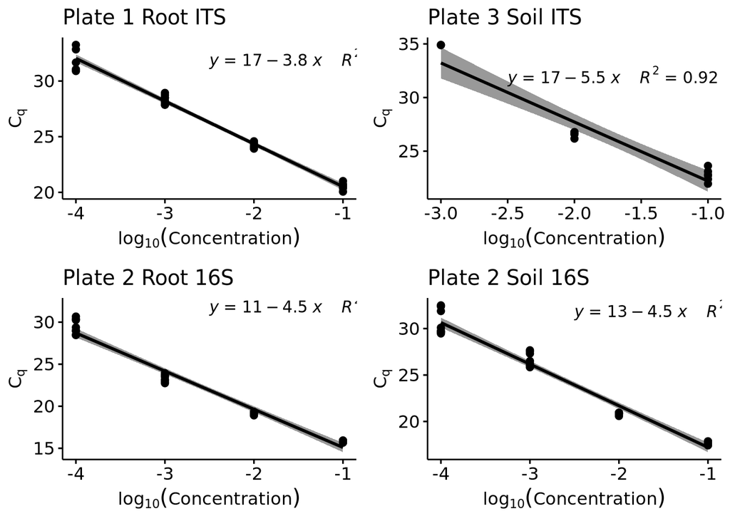

```r
plot_standard_curve(
  combined_standard, combined_standard_curve,
  name = "combined_standard_curves.png"
)
```

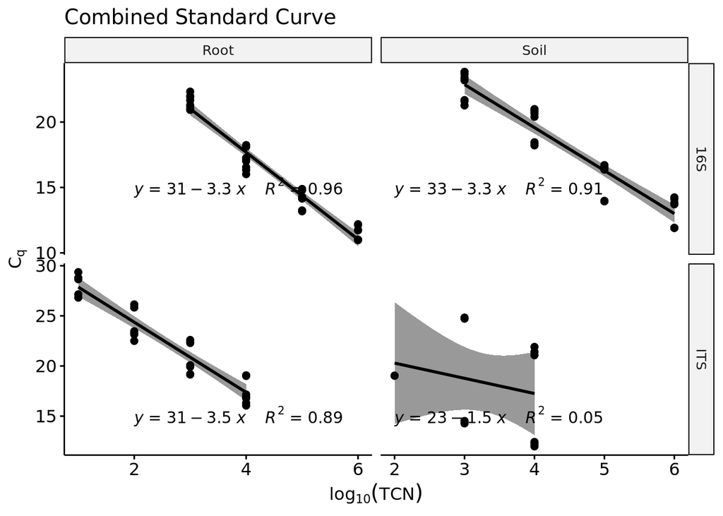

```r
# combined_standard[Target == "ITS" & Type == "Soil" & Dilution == 1000]

bac_initial_copies <- 1e7
fun_initial_copies <- 1e5

# Add TCN to combined standard from dilution range from initial copies based on concentration of standards
combined_standard[Target == "ITS", TCN := Concentration * fun_initial_copies]
combined_standard[Target == "16S", TCN := Concentration * bac_initial_copies]
combined_standard[, log10_TCN := log10(TCN)]

# Plot TCN vs Cq
ggscatter(
  combined_standard, x = "log10_TCN", y = "Cq_adjusted",
  add = "reg.line", conf.int = TRUE
) +
  stat_regline_equation(
    aes(label = paste(
      after_stat(eq.label), after_stat(rr.label), sep = "~~~~"
    )),
    label.x = 2, label.y = 15
  ) +
  facet_grid(Target ~ Type, scales = "free") +
  ggtitle("Combined Standard Curve") +
  xlab(TeX("$\\log_{10}(TCN)$")) +
  ylab(TeX("$C_q$"))
```

```r
ggsave(
  plot = last_plot(), path = fig_dir, width = 8, height = 6,
  filename = "TCN_standards.png"
)

# Plot TCN vs Cq_adjusted for each combination of Target and Type
# ggplot(combined_standard, aes(x = log10(TCN), y = Cq_adjusted)) +
#   geom_point() +
#   geom_smooth(method = "lm", se = TRUE) +
#   stat_regline_equation(
#     aes(label = paste(after_stat(eq.label), after_stat(rr.label), sep = "~~~~")),
#     label.x = 0.5, label.y = 15
#   ) +
#   facet_grid(Target ~ Type, scales = "free") +
#   ggtitle("Combined Standard Curves") +
#   xlab(TeX("$\\log_{10}(TCN)$")) +
#   ylab(TeX("$C_q$"))
```

### Standard curve copy number

```r
# Calculate TCN for standards
plates <- lapply(plates, function(plate) {
  plate$standards[Target == "ITS", TCN := Concentration * fun_initial_copies]
  plate$standards[Target == "16S", TCN := Concentration * bac_initial_copies]
  plate$standards[, log10_TCN := log10(TCN)]
  plate
})


# Calculate standard curves for each plate using TCN
plates <- lapply(plates, function(plate) {
  plate$tcn_standard_curve <- calculate_standard_curve(
    plate$standards, adjust_cq = FALSE, use_tcn = TRUE
  )
  plate
})


# Print TCN standard curves
for (plate in plates) {
  kbl(
    plate$tcn_standard_curve, digits = 2,
    caption = paste("Plate", plate$plate, "TCN standard curve")
  )
}
```

## Repeats

Repeat plate 3 soil ITS due to poor soil standard curve.

```r
# Print samples in which all reps have been flagged as outliers
repeats <- function(data) {
  data[
    Content == "Sample",
    .SD[all(Outlier != "ok")],
    by = .(Sample, Target)
  ][
    , .(Plate, Type, Target, Sample, Outlier = "outliers")
  ][
    , .SD[1], by = .(Sample, Target)
  ][
    order(Sample)
  ]
}


# for (plate in plates) {
#   kbl(
#     repeats(plate$samples),
#     caption = paste("Plate", plate$plate, "repeats"),
#     digits = 2
#   )
# }

kbl(
  repeats(plates$plate_4$samples),
  caption = paste("Plate", plates$plate_4$plate, "repeats"),
  digits = 2
)
```

Plate 4 repeats

[output not shown]

```r
kbl(
  repeats(plates$plate_5$samples),
  caption = paste("Plate", plates$plate_5$plate, "repeats"),
  digits = 2
)
```

Plate 5 repeats

[output not shown]

## Sample copy number

Calculate the theoretical copy number (TCN) of each sample based on the standard curve using the equation:

$$dilution \times 10^{(C_{q} - intercept)/slope}$$

```r
#` Calculate TCN for samples
calculate_tcn <- function(data, standard_curve) {
  standard_curve <- standard_curve[Type == "Root"] # only use root standard curve
  data[
    standard_curve,
    on = .(Target),
    ':='(
      TCN = Dilution * 10 ^ ((Cq - i.Intercept) / i.Slope),
      TCN_adjusted = Dilution * 10 ^ ((Cq_adjusted - i.Intercept) / i.Slope)
    )
  ]
}


plates <- lapply(plates, function(plate) {
  calculate_tcn(plate$samples, plate$tcn_standard_curve)
  plate
})
```

## Sample summary

Calculate the mean and standard deviation of the TCN for each sample.

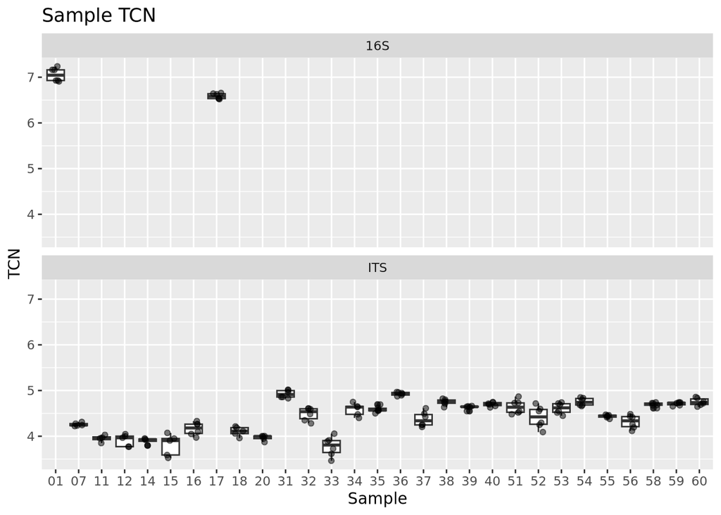

```r
#' Calculate sample summary statistics
sample_summary <- function(data) {
  data[
    Content == "Sample",
    .(Mean = mean(TCN), SD = sd(TCN), N = .N),
    by = .(Sample, Target)
  ][
    order(Sample)
  ]
}


plates <- lapply(plates, function(plate) {
  plate$samples_summary <- sample_summary(plate$samples)
  plate
})


ggplot(plates$plate_5$samples, aes(x = Sample, y = log10(TCN))) +
  geom_boxplot() +
  geom_jitter(width = 0.2, alpha = 0.5) +
  ggtitle("Sample TCN") +
  xlab("Sample") +
  ylab("TCN") +
  theme("ggpubr") +
  facet_wrap(~ Target, ncol = 1)
```

```r
ggsave(
  plot = last_plot(), path = fig_dir, width = 8, height = 6,
  filename = "sample_tcn.png"
)
```

## Combined data

```r
combined_data <- rbindlist(lapply(plates, function(plate) plate$samples))
```

## Repeats

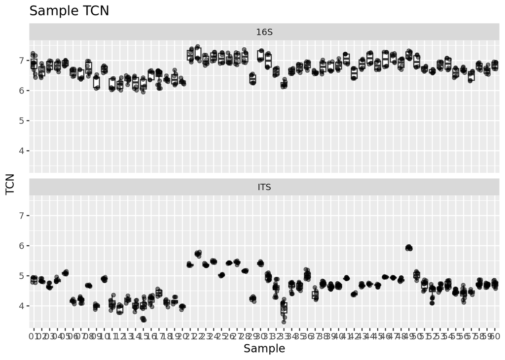

```r
# Calculate z score for each replicate
combined_data[, z_score := (TCN - mean(TCN)) / sd(TCN), by = .(Sample, Target)]

combined_data[, z_score := scale(TCN), by = .(Sample, Target)]

# combined_data[abs(z_score) > 1.5][order(Target, Sample)]

ggplot(combined_data, aes(x = Sample, y = log10(TCN))) +
  geom_boxplot() +
  geom_jitter(width = 0.2, alpha = 0.5) +
  facet_wrap(~ Target, ncol = 1) +
  ggtitle("Sample TCN") +
  xlab("Sample") +
  ylab("TCN") +
  theme("ggpubr")
```

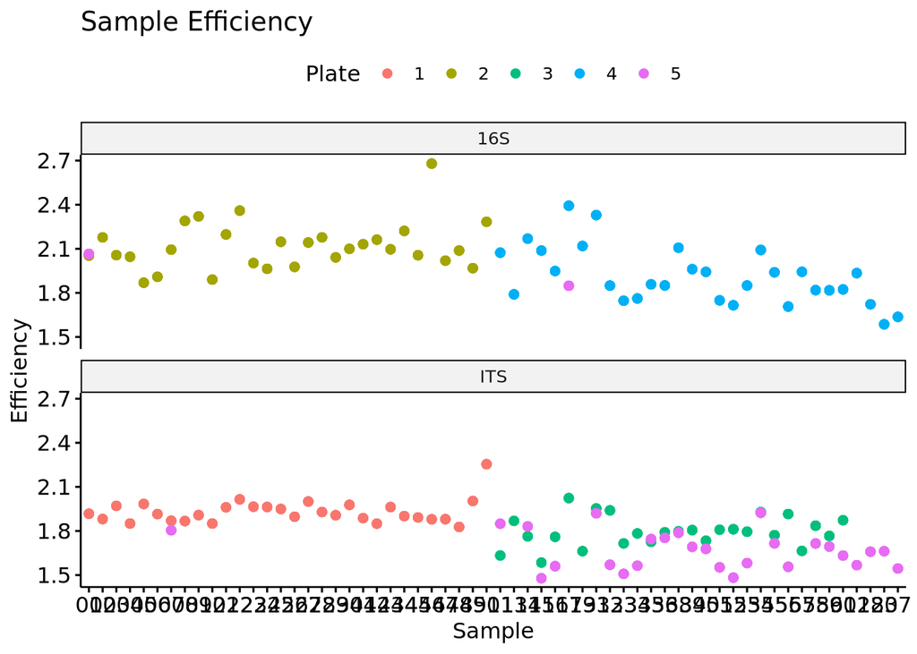

```r
ggsave(
  plot = last_plot(), path = fig_dir, width = 8, height = 6,
  filename = "combined_sample_tcn.png"
)

ggscatter(
  combined_data[, Plate := factor(Plate)],
  x = "Sample", y = "Efficiency", color = "Plate"
) +
  facet_wrap(~ Target, ncol = 1) +
  ggtitle("Sample Efficiency")
```

```r
ggsave(
  plot = last_plot(), path = fig_dir, width = 8, height = 6,
  filename = "combined_sample_efficiency.png"
)
```

## Summary

Calculate the mean and standard deviation of the TCN for each sample.

Calculate TCN per mg of sample. 2 % of the sample mass was used for DNA extraction.

```r
summary <- combined_data[,
  .(mean_TCN = mean(TCN), sd_TCN = sd(TCN), N = .N),
  by = .(Target, Sample)
]

# Combined with sample mass
sample_mass <- fread(file.path(data_dir, "qPCR", "sample_mass.csv"))[, Sample := sprintf("%02d", Sample)]
summary <- merge(summary, sample_mass, by = "Sample")

summary[, TCN_mg := mean_TCN / (mg * 2 / 100)]

summary[, Sample := paste0("HM", Sample)]

kbl(summary)
```

| Sample | Target | mean_TCN | sd_TCN | N | mg | TCN_mg |
| --- | --- | --- | --- | --- | --- | --- |
| HM01 | ITS | 77872.898 | 14251.629 | 6 | 20.2 | 192754.698 |
| HM01 | 16S | 8693464.139 | 4783365.236 | 11 | 20.2 | 21518475.592 |
| HM02 | ITS | 67318.069 | 7144.708 | 6 | 19.9 | 169140.878 |
| HM02 | 16S | 4804805.869 | 2146391.319 | 6 | 19.9 | 12072376.554 |
| HM03 | ITS | 44394.965 | 7031.829 | 6 | 20.9 | 106208.051 |
| HM03 | 16S | 7074331.063 | 2470934.405 | 6 | 20.9 | 16924236.993 |
| HM04 | ITS | 71633.731 | 10904.069 | 6 | 20.7 | 173028.335 |
| HM04 | 16S | 6924871.072 | 2383389.432 | 6 | 20.7 | 16726741.721 |
| HM05 | ITS | 123256.293 | 10782.592 | 6 | 20.5 | 300625.105 |
| HM05 | 16S | 8272359.698 | 1790807.694 | 6 | 20.5 | 20176487.068 |
| HM06 | ITS | 14348.010 | 2068.188 | 5 | 20.8 | 34490.409 |
| HM06 | 16S | 4194943.230 | 1071598.941 | 6 | 20.8 | 10083998.148 |
| HM07 | ITS | 16658.705 | 2297.419 | 10 | 20.8 | 40044.964 |
| HM07 | 16S | 3473712.495 | 1351987.912 | 5 | 20.8 | 8350270.420 |
| HM08 | ITS | 47050.769 | 2183.511 | 6 | 20.2 | 116462.300 |
| HM08 | 16S | 6040020.349 | 2931610.118 | 6 | 20.2 | 14950545.418 |
| HM09 | ITS | 9868.544 | 1528.372 | 6 | 20.6 | 23952.776 |
| HM09 | 16S | 2256047.936 | 991771.003 | 5 | 20.6 | 5475844.505 |
| HM10 | ITS | 80116.991 | 6986.885 | 6 | 20.6 | 194458.717 |
| HM10 | 16S | 5247436.153 | 1237237.150 | 6 | 20.6 | 12736495.517 |
| HM11 | ITS | 12610.150 | 5026.028 | 8 | 51.8 | 12171.959 |
| HM11 | 16S | 1685503.628 | 750689.952 | 5 | 51.8 | 1626934.004 |
| HM12 | 16S | 1706293.846 | 677192.073 | 5 | 50.4 | 1692751.832 |
| HM12 | ITS | 8435.073 | 2411.709 | 5 | 50.4 | 8368.128 |
| HM13 | ITS | 16410.463 | 4044.454 | 4 | 51.6 | 15901.612 |
| HM13 | 16S | 2438145.582 | 586661.521 | 6 | 51.6 | 2362544.169 |
| HM14 | ITS | 10703.986 | 3306.933 | 8 | 49.8 | 10746.973 |
| HM14 | 16S | 1993566.942 | 915387.052 | 6 | 49.8 | 2001573.235 |
| HM15 | ITS | 10673.092 | 5634.564 | 9 | 53.2 | 10031.101 |
| HM15 | 16S | 1693785.811 | 782742.949 | 5 | 53.2 | 1591903.958 |

[output cut: 90 more lines]

```r
# Export as csv
fwrite(summary, file.path(data_dir, "abundance.csv"))
```